# DMR

Elouan Bethuel

28 May, 2024

# 1 R packages requirements

Methylator runs R scripts and uses : - [MethylKit](https://github.com/al2na/methylKit) package to handle DNA methylation data.  
- [bsseq](https://github.com/kdkorthauer/dmrseq) package to infere differentially methylated regions (DMRs) from bisulfite sequencing

[Conda](https://docs.conda.io/en/latest/) within a [Singularity/Apptainer](https://apptainer.org/) image handles R version and package dependencies for improved reproducibility. Refer to the ‘R session information’ section for version details.

```r
# load packages
library(BiocParallel)
library(ggplot2)
library(dplyr)
library(tidyr)
library(GenomicFeatures)
library(annotatr)
library(FactoMineR)
library(factoextra)
library(bsseq)
library(yaml)
library(dmrseq)
library(plyranges)
library(annotatr)
library(GenomicRanges)
library(stringr)
library(methylKit)
```

# 2 Configuration and settings

Read analysis parameters from ‘config_wgbs.yaml’ or ‘config_nanopore.yaml’ and extract sample names and groups from the corresponding metadata file.

```r
# load the config file
yaml.file <- yaml.load_file('config_ongoing_run.yaml')

# extract the information from the yaml file
ORG <- yaml.file$ASSEMBLY
DESTRAND<- yaml.file$DESTRAND
MINCOV <- yaml.file$MINCOV
COV.PERC <- yaml.file$COV.PERC
DMR_TYPE <- yaml.file$DMR_TYPE
MIN_CPG <- yaml.file$MIN_CPG
MAX_GAP <- yaml.file$MAX_GAP
CUTOFF <- yaml.file$CUTOFF
FDR <- yaml.file$FDR
UNITE <- yaml.file$UNITE

# extract the metadata
meta <- read.table(yaml.file$METAFILE, sep='\t', header=T)
knitr::kable(meta, "pipe")
```

| sample | group |
| --- | --- |
| SRR9016926_sub500000_chr19 | WT |
| SRR9016927_sub500000_chr19 | 1KO |
| SRR9016928_sub500000_chr19 | DKO |
| SRR11806587_sub500000_chr19 | WT |
| SRR11806588_sub500000_chr19 | 1KO |
| SRR11806589_sub500000_chr19 | DKO |

```r
# set colors
full.color = "#de0000"
high.color = "#e17e65"
mid.color  = "#c6c6c6"
low.color = "#7c6fac"
unmeth.color = "#0f208f"
hyper.color = "#de0000"
hypo.color = "#0f208f"
not.color = "#c6c6c6"
```

# 3 Configuration file parameters

- Minimum coverage - MINCOV : 5 à voir si cérer aussi une variable sépciale en DMR
- Discard the bases that have more than COV.PERC the percentile of coverage - COV.PERC : 99.9
- Minimum number of CpGs to consider for a candidate DMR : 5
- Maximum number of bp in between neighboring CpGs to be included in the same DMR : 1000
- Significant difference threshold to consider a CpG as a candidate for inferring a DMR: 0.05
- Qvalue for significant differential methylation regions : 0.05
- Type of DMR selection (regions or blocks) : regions

# 4 Load RData

Methylator takes primary DNA methylation data and generates one RData environment with one MethylRaw object per sample.  
The MethylRaw object stores the following for each CpG:  
- Genomic coordinates (Chrom, Start, End, Strand)  
- Coverage (number of reads)  
- Number of methylated and unmethylated cytosines (for computing the methylation status)  
It contains the total number of CpG, sample_id, genome assembly and methylation context (CpG).

# 5 Convert methylkit to bsseq object

The dmrsseq package manipulates bsseq objects to infer DMRs,  
It is possible to read files produced by Bismark’s methylation extractor (.gz or .bz2 )  
But the Methylkit package offers numerous functions for filtering and unifying samples.  
So we prefer to start with a Methylkit object and convert it into a bsseq object.

[output not shown]

# 6 Plot distribution of methylation values and coverage

Beta values can be interpreted as the proportion of methylation at a given locus.  
Beta values are continuous variables between 0 (CpG site always found unmethylated in sample DNA) and 1 (CpG site always found methylated in sample DNA)

## 6.1 Beta values by group

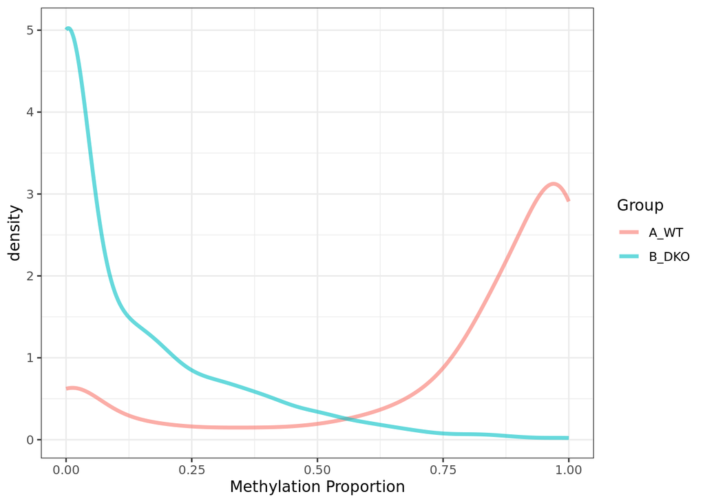

```r
plotEmpiricalDistribution(bs, testCovariate="group")
```

## 6.2 Beta values by sample

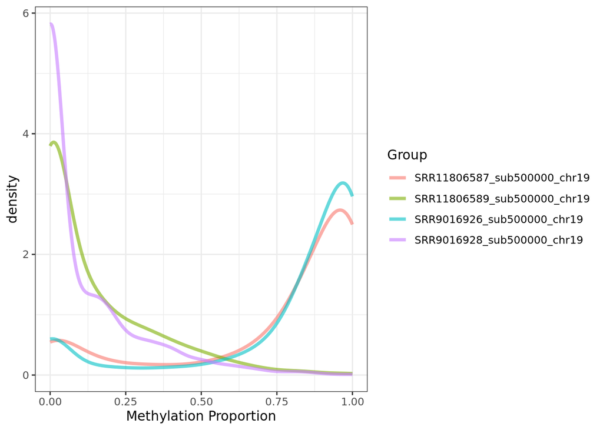

```r
plotEmpiricalDistribution(bs, testCovariate="sample")
```

## 6.3 Coverage plot by group

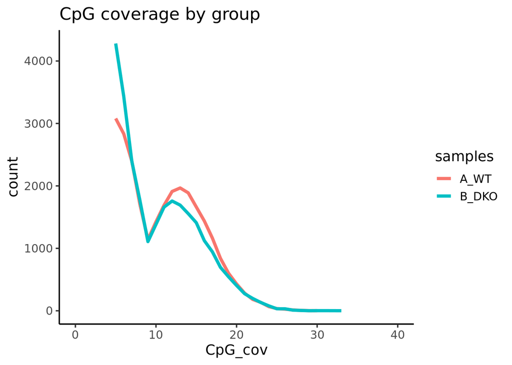

```r
bs_cov <- as.data.frame(getCoverage(bs, type = "Cov"))
colnames(bs_cov) <- meta_cond$group
bs_cov_rsh <- pivot_longer(bs_cov, cols = meta_cond$group, names_to = "samples", values_to = "CpG_cov")

plt_cov <- ggplot(data = bs_cov_rsh,  aes(x = CpG_cov, color = samples)) +
            geom_line(stat = "count", size = 1.5) +
            coord_cartesian(xlim = c(0, 40)) +
            ggtitle("CpG coverage by group") + theme_classic(base_size = 14)

plt_cov
```

## 6.4 Coverage plot by sample

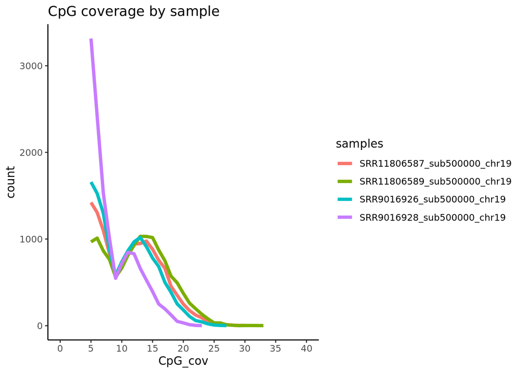

```r
bs_cov <- as.data.frame(getCoverage(bs, type = "Cov"))
colnames(bs_cov) <- meta_cond$sample
bs_cov_rsh <- pivot_longer(bs_cov, cols = meta_cond$sample, names_to = "samples", values_to = "CpG_cov")

plt_cov <- ggplot(data = bs_cov_rsh,  aes(x = CpG_cov, color = samples)) +
            geom_line(stat = "count", size = 1.5) +
            coord_cartesian(xlim = c(0, 40)) +
            scale_x_continuous(breaks = seq(0, 40, 5)) +
            ggtitle("CpG coverage by sample") + theme_classic()

plt_cov
```

# 7 Build annotations

When DMRs are inferred and then displayed with dmrseq, annotations can be associated with them  
(genes or CpG islands present in the region or nearby) using an annoTrack object.  
To build annoTrack we used the “annotation” object produced with the ‘Annotatr.R’ script using the annotar package  
[annotatr](https://bioconductor.org/packages/devel/bioc/vignettes/annotatr/inst/doc/annotatr-vignette.html)  
The annoTrack object looks like this:

```r
annoTrack <- GenomicRanges::GRangesList(CpG = annotations , Genes = annotations[annotations$type == paste0(ORG,"_genes")], compress = FALSE)

annoTrack$CpG$type <- ifelse(annoTrack$CpG$type == paste0(ORG,"_cpg_islands") , "islands",
                      ifelse(annoTrack$CpG$type ==  paste0(ORG,"_cpg_shores") , "shores",
                      ifelse(annoTrack$CpG$type ==  paste0(ORG,"_cpg_shelves"), "shelves" , "inter")))

annoTrack$Genes$symbol <- annoTrack$Genes$gene_id
head(annoTrack)
```

```
## GRangesList object of length 2:
## $CpG
## GRanges object with 84476 ranges and 5 metadata columns:
##           seqnames          ranges strand |          id                tx_id
##              <Rle>       <IRanges>  <Rle> | <character>          <character>
##       [1]    chr19 3946193-3946269      - |   introns:1                 <NA>
##       [2]    chr19 3946448-3946603      - |   introns:2                 <NA>
##       [3]    chr19 3946722-3946794      - |   introns:3                 <NA>
##       [4]    chr19 3946903-3947037      - |   introns:4                 <NA>
##       [5]    chr19 3947231-3947467      - |   introns:5                 <NA>
##       ...      ...             ...    ... .         ...                  ...
##   [84472]    chr19 5250832-5256331      - |    gene:263 ENSMUSG00002076406.1
##   [84473]    chr19 6189762-6195261      + |    gene:264 ENSMUSG00002076495.1
##   [84474]    chr19 5848614-5854113      - |    gene:265 ENSMUSG00002076626.1
##   [84475]    chr19 5894566-5900065      - |    gene:266 ENSMUSG00002076763.1
##   [84476]    chr19 5893966-5899465      - |    gene:267 ENSMUSG00002076852.1
##                        gene_id    symbol        type
##                    <character> <logical> <character>
##       [1]                 <NA>      <NA>       inter
##       [2]                 <NA>      <NA>       inter
##       [3]                 <NA>      <NA>       inter
##       [4]                 <NA>      <NA>       inter
##       [5]                 <NA>      <NA>       inter
##       ...                  ...       ...         ...
##   [84472] ENSMUSG00002076406.1      <NA>       inter
##   [84473] ENSMUSG00002076495.1      <NA>       inter
##   [84474] ENSMUSG00002076626.1      <NA>       inter
##   [84475] ENSMUSG00002076763.1      <NA>       inter
##   [84476] ENSMUSG00002076852.1      <NA>       inter
##   -------
##   seqinfo: 26 sequences from mm39 genome
##
## $Genes
## GRanges object with 267 ranges and 5 metadata columns:
##         seqnames          ranges strand |          id                 tx_id
##            <Rle>       <IRanges>  <Rle> | <character>           <character>
##     [1]    chr19 3946050-3957133      - |      gene:1 ENSMUSG00000001750.17
##     [2]    chr19 5738770-5752893      + |      gene:2 ENSMUSG00000004054.10
##     [3]    chr19 4320208-4333165      - |      gene:3 ENSMUSG00000005986.17
##     [4]    chr19 4850597-4861662      - |      gene:4 ENSMUSG00000006456.11
##     [5]    chr19 4911244-4927937      - |      gene:5  ENSMUSG00000006457.5
##     ...      ...             ...    ... .         ...                   ...
##   [263]    chr19 5251226-5251331      - |    gene:263  ENSMUSG00002076406.1
##   [264]    chr19 6194762-6194881      + |    gene:264  ENSMUSG00002076495.1
##   [265]    chr19 5849028-5849113      - |    gene:265  ENSMUSG00002076626.1
##   [266]    chr19 5894944-5895065      - |    gene:266  ENSMUSG00002076763.1
##   [267]    chr19 5894314-5894465      - |    gene:267  ENSMUSG00002076852.1
##                       gene_id                symbol        type
##                   <character>           <character> <character>
##     [1] ENSMUSG00000001750.17 ENSMUSG00000001750.17  mm39_genes
##     [2] ENSMUSG00000004054.10 ENSMUSG00000004054.10  mm39_genes
##     [3] ENSMUSG00000005986.17 ENSMUSG00000005986.17  mm39_genes
##     [4] ENSMUSG00000006456.11 ENSMUSG00000006456.11  mm39_genes
##     [5]  ENSMUSG00000006457.5  ENSMUSG00000006457.5  mm39_genes
##     ...                   ...                   ...         ...
##   [263]  ENSMUSG00002076406.1  ENSMUSG00002076406.1  mm39_genes
##   [264]  ENSMUSG00002076495.1  ENSMUSG00002076495.1  mm39_genes
##   [265]  ENSMUSG00002076626.1  ENSMUSG00002076626.1  mm39_genes
##   [266]  ENSMUSG00002076763.1  ENSMUSG00002076763.1  mm39_genes
##   [267]  ENSMUSG00002076852.1  ENSMUSG00002076852.1  mm39_genes
##   -------
##   seqinfo: 26 sequences from mm39 genome
```

# 8 Detecting DMR, type : regions

According to the bioconductor drmseq vignette, [dmrseq-vignette](https://bioconductor.org/packages/devel/bioc/vignettes/dmrseq/inst/doc/dmrseq.html#5_Exploring_and_exporting_results) the default smoothing parameters are designed to focus on local DMRs.  
In some applications, it is of interest to effectively ‘zoom out’ in order to detect larger (lower-resolution) methylation blocks on the order of hundreds of thousands to millions of bases.  
To do so, you can set the block argument to true, which will only include candidate regions with at least blockSize basepairs (default = 5000) and redefine the default smoothing parameters.

```r
register(MulticoreParam(32))
#register(SerialParam)

if(DMR_TYPE == "regions"){
  dmr_obj <- try(dmrseq(bs=bs,
                    cutoff = CUTOFF,
                    testCovariate="group",
                    smooth = FALSE,
                    bpSpan = 1000,
                    maxGap = MAX_GAP,
                    minInSpan = 10,
                    maxGapSmooth = 5000,
                    maxPerms = 20,
                    minNumRegion = MIN_CPG))
}


if(DMR_TYPE == "blocks"){
  dmr_obj <- try(dmrseq(bs= bs,
                        cutoff = CUTOFF,
                        testCovariate= "group",
                        block = TRUE,
                        minInSpan = 500,
                        bpSpan = 5e4,
                        maxGapSmooth = 1e6,
                        maxGap = 5e3,))
}
```

```r
if (typeof(dmr_obj) == "character"){
    print("No candidate regions, try to modifie parameters")
    notempty.dmr = FALSE
} else{
  notempty.dmr = TRUE
  head(dmr_obj)
}
```

```
## GRanges object with 6 ranges and 7 metadata columns:
##       seqnames          ranges strand |         L      area      beta      stat
##          <Rle>       <IRanges>  <Rle> | <integer> <numeric> <numeric> <numeric>
##   [1]    chr19 4703169-4716131      * |        87   76.4647  -2.32870  -70.3302
##   [2]    chr19 3725719-3733760      * |        42   37.8285  -2.43657  -57.4863
##   [3]    chr19 3471755-3481961      * |        69   59.6609  -2.31223  -54.2632
##   [4]    chr19 5378022-5387895      * |        69   58.8808  -2.25488  -53.0051
##   [5]    chr19 5628599-5639216      * |        95   80.1588  -2.24347  -52.4878
##   [6]    chr19 4786999-4805142      * |       144  119.8860  -2.23860  -52.3087
##             pval       qval       index
##        <numeric>  <numeric>   <IRanges>
##   [1] 0.00142857 0.00152723   7130-7216
##   [2] 0.00142857 0.00152723   2282-2323
##   [3] 0.00142857 0.00152723   1132-1200
##   [4] 0.00142857 0.00152723 11087-11155
##   [5] 0.00142857 0.00152723 12783-12877
##   [6] 0.00142857 0.00152723   7571-7714
##   -------
##   seqinfo: 1 sequence from an unspecified genome; no seqlengths
```

```r
if( (notempty.dmr == TRUE) && (length(dmr_obj) == 0)){
  notempty.dmr = FALSE
}
```

# 9 Significant DMRs (regions)

Select DMRs with a q-value (FDR) < 0.05

```r
if(notempty.dmr){
  sigdmr <- dmr_obj[dmr_obj$qval < FDR,]

  if(length(sigdmr) > 0){
    nb_sig <- length(sigdmr)
    nb_nosig <- length(dmr_obj)-nb_sig
    df_sig <- data.frame(length(dmr_obj), nb_sig, nb_nosig)
    percentage_sig <- c(100, round(((nb_sig/length(dmr_obj))*100),2), round(((nb_nosig/length(dmr_obj))*100),2))
    colnames(df_sig) <- c("all", 'Significant', "Non-significant")
    df_sig <-  tidyr::gather(df_sig, key = "Status", value = "count")

    sig_bar <- ggplot(df_sig, aes(x = Status, y = count, fill = Status)) +
                      geom_bar(position = "dodge" , stat = "identity", alpha=0.5, colour = "black") +
                      labs(title = paste0("Number of DMRs significants, FDR: ", FDR), y = "Number of DMRs") +
                      scale_color_brewer(palette="Dark2") +
                      geom_text(aes(label = paste0(percentage_sig, "%" )), position = position_stack(vjust = 0.5), size = 5)
                      theme_minimal()+theme_classic()

  }else{
    print("No significant found")
    sigdmr <- data.frame()
    sig_bar <- data.frame()
  }
}else{
  print("No candidate, try to modifie parameters")
  sigdmr <- data.frame()
  sig_bar <- data.frame()
}
```

[output not shown]

[output cut: 356 more lines]

[output not shown]

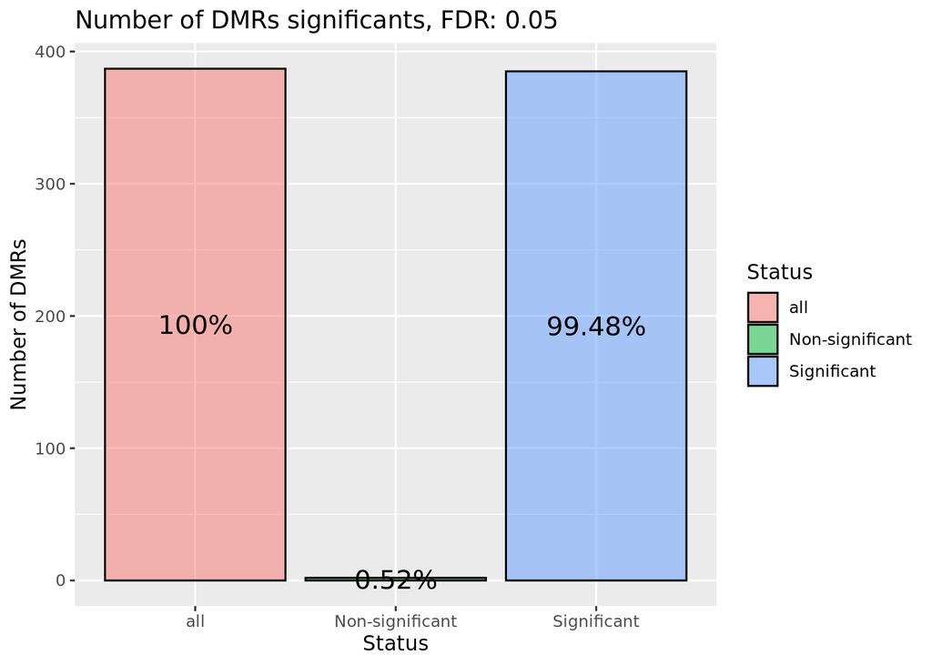

```r
sig_bar
```

```r
suppressWarnings(rm(df_sig))
suppressWarnings(rm(precentage_sig))
suppressWarnings(rm(nb_sig, nb_nosig))
```

# 10 Statistics about DMRs

## 10.1 Boxplot of number of CpG in DMRs and DMRs width

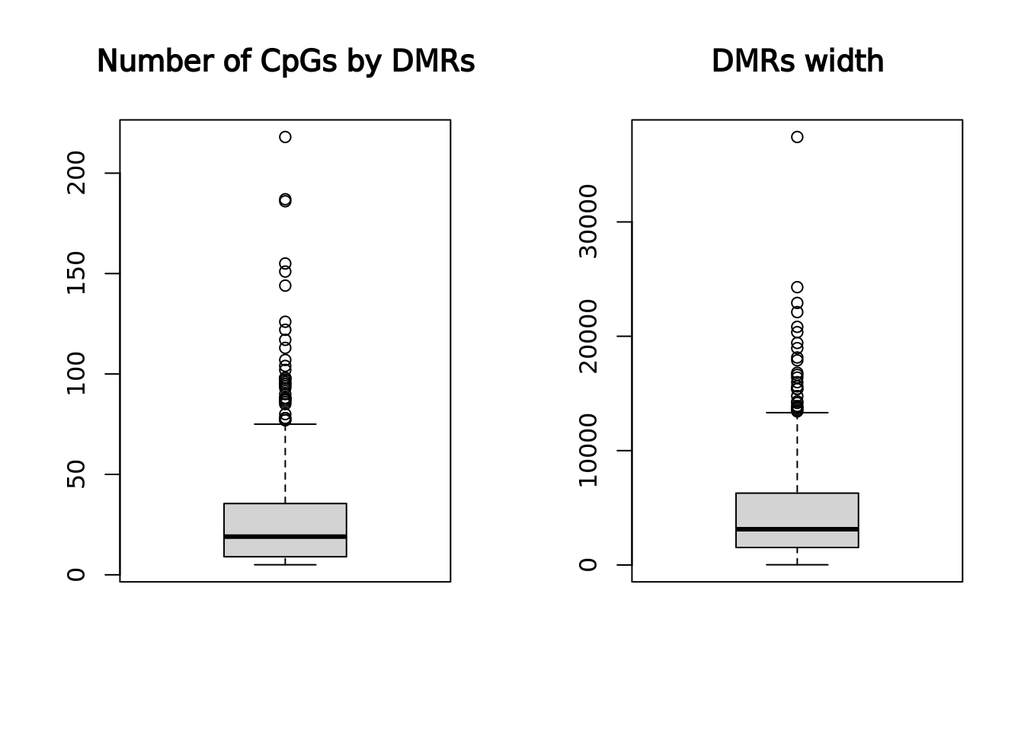

```r
if(notempty.dmr){
  df_dmr <- as.data.frame(dmr_obj)
  par(mfrow = c(1,2))
  boxplot(df_dmr$L)
  title("Number of CpGs by DMRs")
  boxplot(df_dmr$width)
  title("DMRs width")
}else{
  print("No candidate, try to modifie parameters")
}
```

## 10.2 Boxplot of number of CpG in DMRs and DMRs width for significant DMRs only

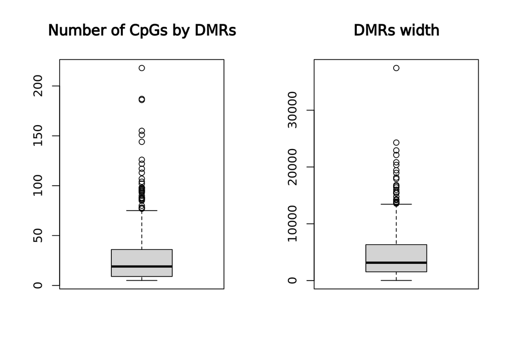

```r
if(length(sigdmr) > 0){
  df_dmr_sig <- as.data.frame(sigdmr)
  par(mfrow = c(1,2))
  boxplot(df_dmr_sig$L)
  title("Number of CpGs by DMRs")
  boxplot(df_dmr_sig$width)
  title("DMRs width")
}else{
  print("No significants candidate, try to modifie parameters")
}
```

## 10.3 Plot number of hypo and hyper-methylated DMRs

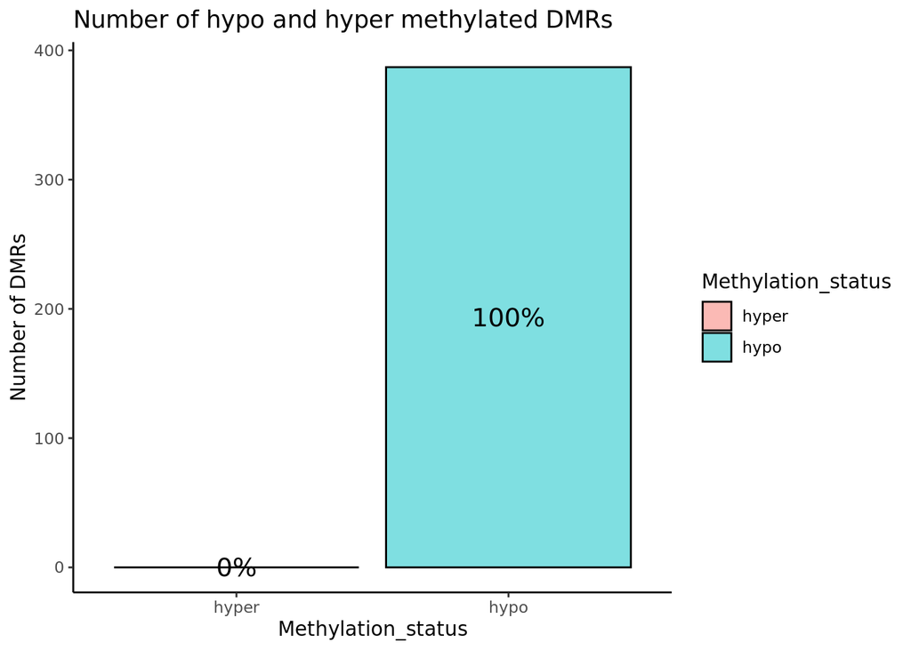

```r
if(notempty.dmr){
  dmr_hyper <- sum(dmr_obj$stat > 0)
  dmr_hypo <- sum(dmr_obj$stat < 0)
  df_meth <- data.frame(dmr_hyper, dmr_hypo)
  colnames(df_meth) <- c("hyper","hypo")
  df_meth <-  tidyr::gather(df_meth, key = "Methylation_status", value = "count")
  perc_meth <- c(round(((dmr_hyper/length(dmr_obj))*100),2), round(((dmr_hypo/length(dmr_obj))*100),2))

  plot_meth <- ggplot(df_meth, aes(x = Methylation_status, y = count, fill = Methylation_status)) +
                        geom_bar(position = "dodge" , stat = "identity", alpha=0.5, colour = "black") +
                        labs(title = "Number of hypo and hyper methylated DMRs ", y = "Number of DMRs") +
                        scale_color_brewer(palette="Dark2") +
                        geom_text(aes(label = paste0(perc_meth, "%" )), position = position_stack(vjust = 0.5), size = 5) +
                        theme_minimal() + theme_classic()
}else{
  print("No candidate, try to modifie parameters")
  plot_meth <- data.frame()
}

plot_meth
```

```r
rm(df_meth)
rm(perc_meth)
rm(dmr_hyper, dmr_hypo)
```

## 10.4 Plot number of hypo and hypermethylated DMRs for significant DMRs only

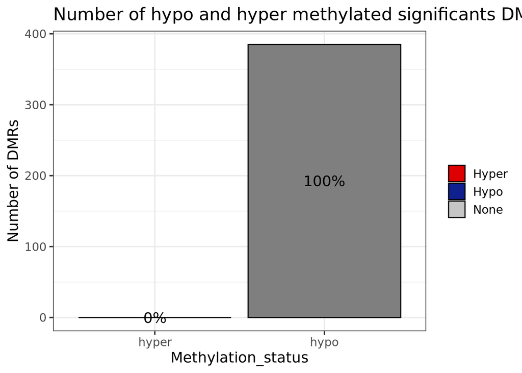

```r
if(length(sigdmr) > 0){
  sigdmr_hyper <- sum(sigdmr$stat > 0)
  sigdmr_hypo <- sum(sigdmr$stat < 0)
  df_sigmeth <- data.frame(sigdmr_hyper, sigdmr_hypo)
  colnames(df_sigmeth) <- c("hyper","hypo")
  df_sigmeth <-  tidyr::gather(df_sigmeth, key = "Methylation_status", value = "count")
  perc_sigmeth <- c(round(((sigdmr_hyper/length(sigdmr))*100),2), round(((sigdmr_hypo/length(sigdmr))*100),2))

  sig_meth <- ggplot(df_sigmeth, aes(x = Methylation_status, y = count, fill = Methylation_status)) +
                        geom_bar(position = "dodge" , stat = "identity", colour = "black") +
                        labs(title = "Number of hypo and hyper methylated significants DMRs ", y = "Number of DMRs") +
                        theme_bw(base_size = 14) +
                        scale_fill_manual("", values=c('Hyper' = hyper.color,
                                                       'Hypo' = hypo.color,
                                                       'None' = not.color)) +
                        geom_text(aes(label = paste0(perc_sigmeth, "%" )), position = position_stack(vjust = 0.5), size = 5)

}else{
  sig_meth <- data.frame()
  print("No significant candidate, try to modifie parameters")
}

sig_meth
```

```r
suppressWarnings(rm(df_sigmeth))
suppressWarnings(rm(perc_sigmeth))
suppressWarnings(rm(sigdmr_hyper, sigdmr_hypo))
```

## 10.5 Plot number of DMRs by chromosome

for each chromosome plot the number of DMRs hypo and hyper methylated

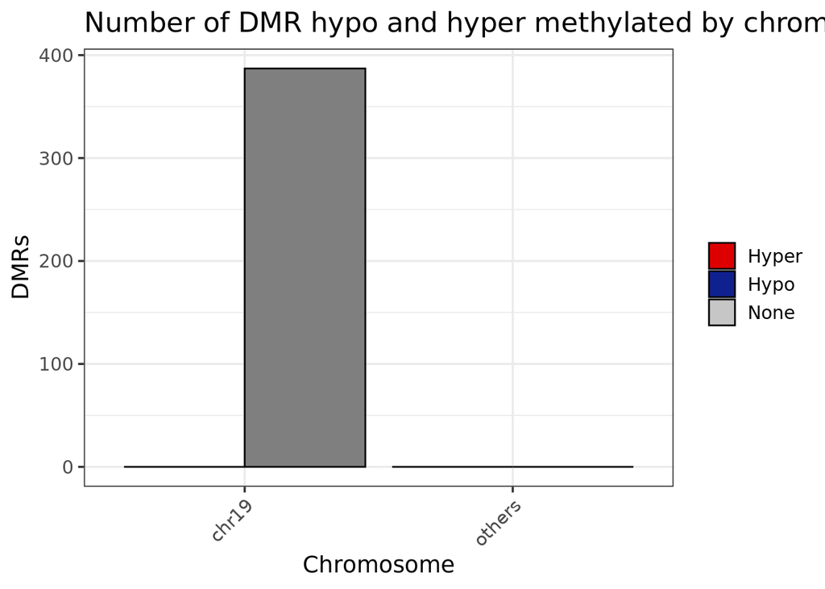

```r
if(notempty.dmr){
  df_dmr <- as.data.frame(dmr_obj)
  df_dmr$seqnames <- as.vector(df_dmr$seqnames)
  df_dmr$status <- ifelse(df_dmr$stat > 0, "hyper", "hypo")

  df <- data.frame(
    chr = df_dmr$seqnames,
    status = df_dmr$status)

  count_per_chromosome <- table(df$chr, df$status)
  count_df <- as.data.frame.matrix(count_per_chromosome)
  count_df$chr <- rownames(count_df)

  # test si absence de hypo ou hyper
  if(dim(count_df)[2] == 2){
    if(colnames(count_df[1]) == "hypo"){
      count_df$hyper <- rep(0, dim(count_df)[1])
    }else{
      count_df$hypo <- rep(0, dim(count_df)[1])
    }
  }

  chr_others <- count_df[1,]
  rownames(chr_others) <- "others"
  chr_others$hypo <- chr_others$hyper <- 0
  chr_others$chr <- "others"

  delete_row <- 0

  for(i in 1:length(count_df$chr)){
    if((nchar(count_df$chr[i]) > 5) == TRUE){
      chr_others$hypo <- (chr_others$hypo + count_df[i,]$hypo)
      chr_others$hyper <- (chr_others$hyper + count_df[i,]$hyper)
      delete_row <- c(delete_row, i)
    }
  }

  if(is.na(delete_row[2]) == FALSE){ # test si il n'y a aucune colonne à remove (delete_row  = 0), car sinon génère des bugs
    count_df <- count_df[-delete_row,]
  }
  count_df<- rbind(count_df, chr_others)
  count_df$chr <- str_sort(count_df$chr, numeric = TRUE)
  count_df_long <- tidyr::gather(count_df, key = "status", value = "count", hypo, hyper)

  hist_dmr_chr <- ggplot(count_df_long, aes(x = chr, y = count, fill = status)) +
                          geom_bar(position = "dodge" , stat = "identity", colour = "black") +
                          labs(title = "Number of DMR hypo and hyper methylated by chromosome",
                               x = "Chromosome",
                               y = "DMRs") +
                          theme_bw(base_size = 14) +
                          scale_fill_manual("", values=c('Hyper' = hyper.color,
                                                           'Hypo' = hypo.color,
                                                           'None' = not.color)) +
                          theme(axis.text.x = element_text(angle = 45, vjust = 1, hjust=1))

  rm(df_dmr, df)
  rm(delete_row)
  rm(count_df, count_df_long)
  rm(chr_others)

}else{
  hist_dmr_chr <- data.frame()
  print("No candidate, try to modifie parameters")
}

hist_dmr_chr
```

# 11 Plot top ten significant DMRs

By default, DMRs are sorted by their q-value

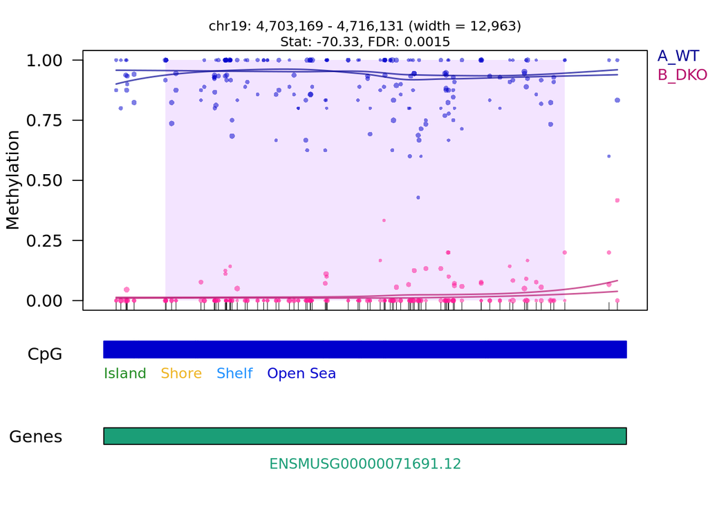

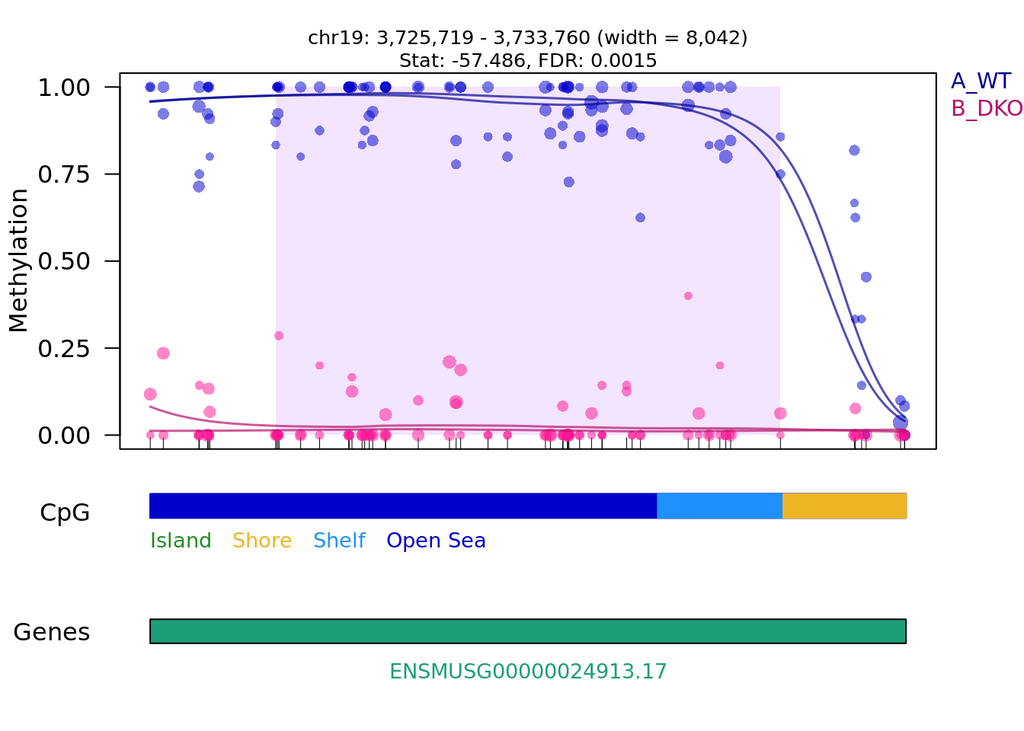

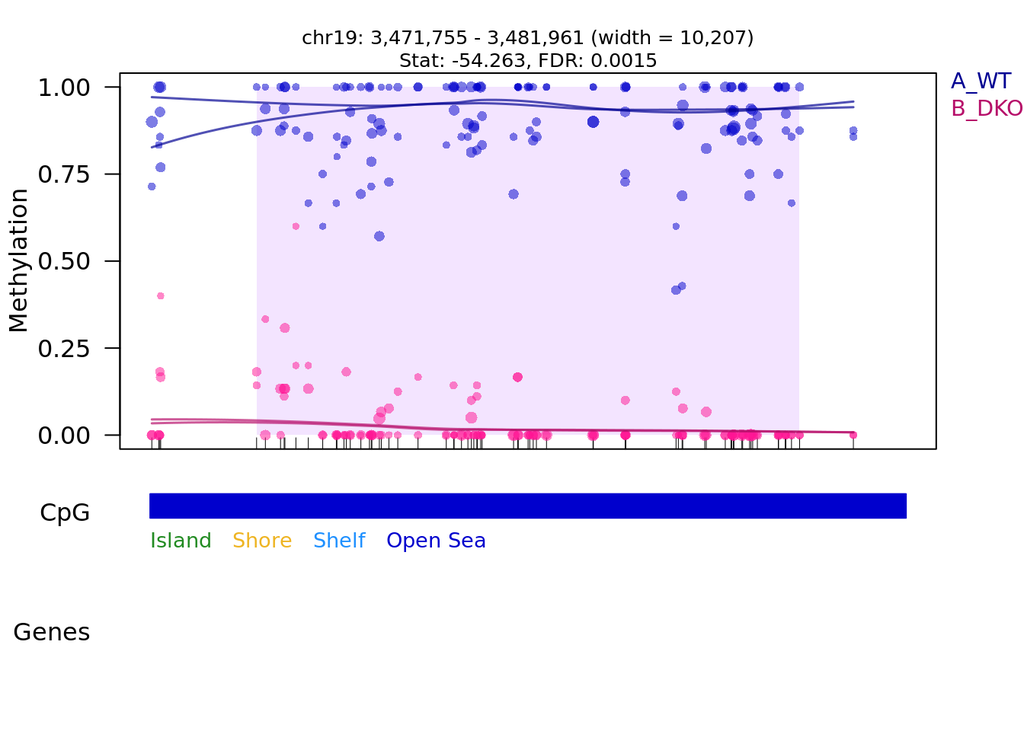

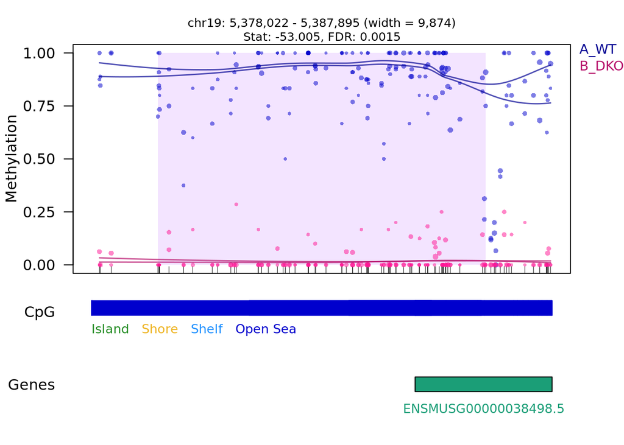

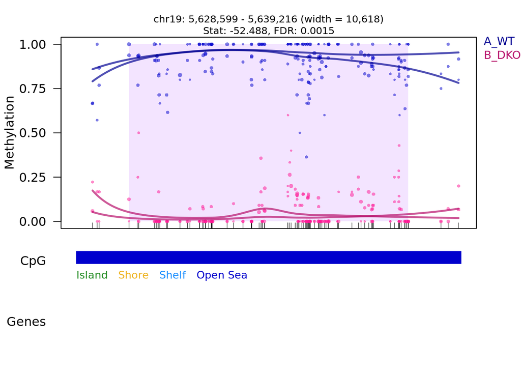

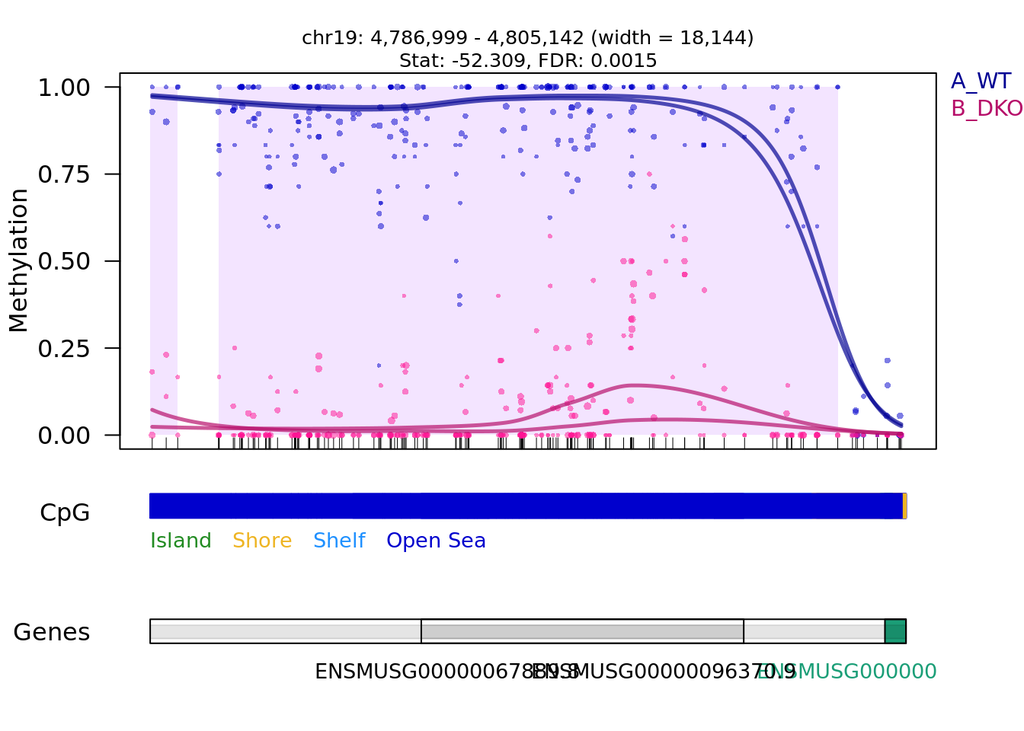

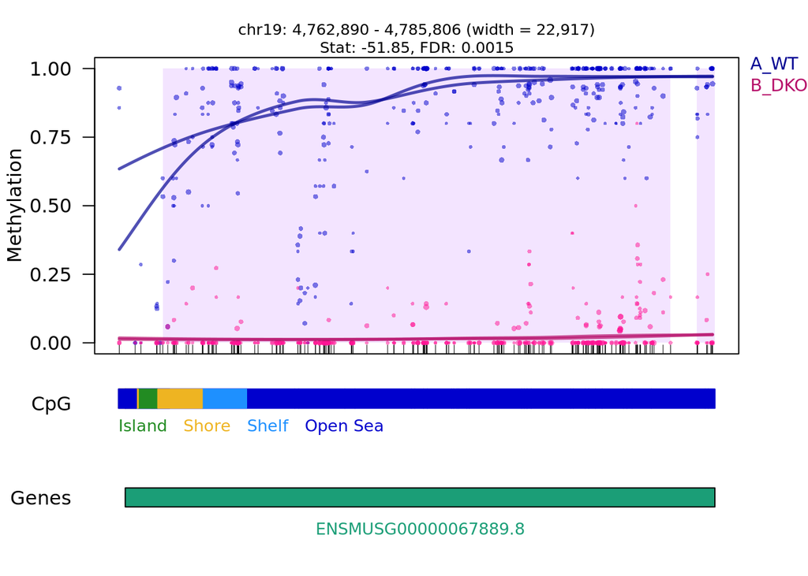

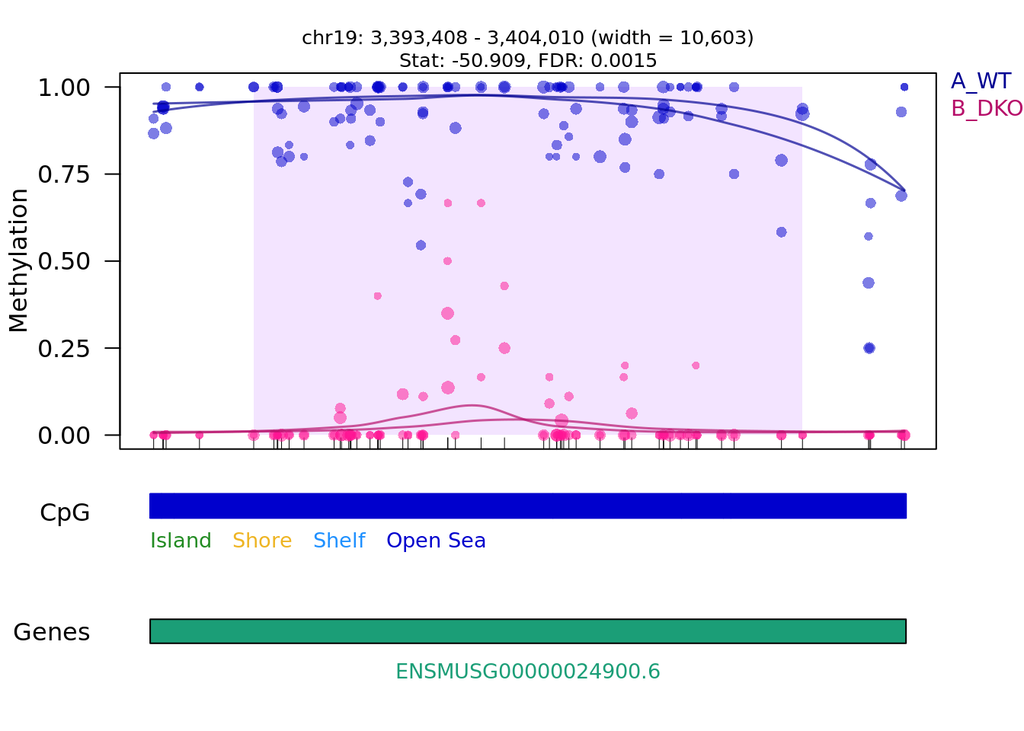

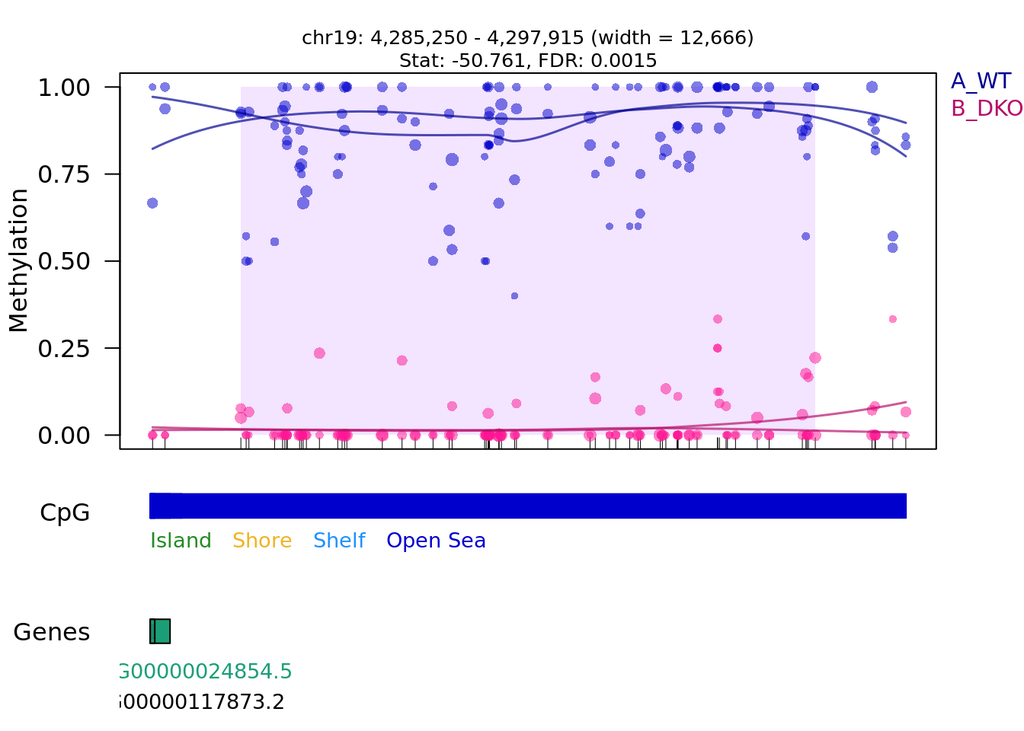

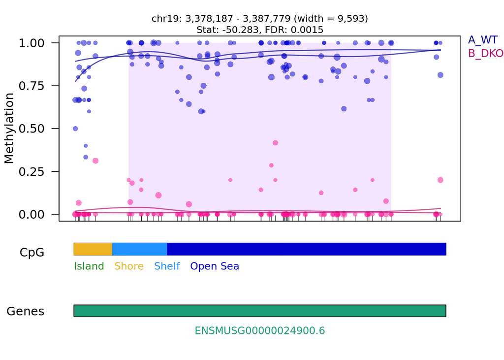

```r
if(length(sigdmr) > 0){
  if(length(sigdmr) >= 10){
    plotDMRs(bs, regions=sigdmr[1:10,], testCovariate="group", extend = 2000, annoTrack = annoTrack, horizLegend = TRUE)
  }else{
    plotDMRs(bs, regions=sigdmr[1:length(dmr_obj),], testCovariate="group", extend = 2000, annoTrack = annoTrack, horizLegend = TRUE)
  }
}else{
  print("Impossible to plot top ten significant DMRs, no candidate, try to modifie parameters")
}
```

# 12 Annot significants DMRs object with genes and promoters only

Annotates significant DMRSs that intersect with genes. Use the Annotatr package. Warning: if several genes or promoters are associated with the same DMRS, create several lines in the CSV file, with the DMR annotated with the different genes. The CSV file is likely to be larger, so DMRs that are not associated with genes are not displayed.

```r
if(length(sigdmr) > 0){
  sigdmr_annot <- annotate_regions(regions = sigdmr, annotations = annotations, ignore.strand = TRUE, quiet = FALSE)
  sigdmr_annot_genes <- sigdmr_annot[sigdmr_annot$annot$type == paste0(ORG, "_genes") | sigdmr_annot$annot$type == paste0(ORG, "_promoters")  , ]
  head(sigdmr_annot_genes)
}else{
  print("No candidate, try to modifie parameters")
  sigdmr_annot <- NULL
  sigdmr_annot_genes <- NULL
}
```

```
## GRanges object with 6 ranges and 8 metadata columns:
##       seqnames          ranges strand |         L      area      beta      stat
##          <Rle>       <IRanges>  <Rle> | <integer> <numeric> <numeric> <numeric>
##   [1]    chr19 4703169-4716131      * |        87   76.4647  -2.32870  -70.3302
##   [2]    chr19 3725719-3733760      * |        42   37.8285  -2.43657  -57.4863
##   [3]    chr19 5378022-5387895      * |        69   58.8808  -2.25488  -53.0051
##   [4]    chr19 5378022-5387895      * |        69   58.8808  -2.25488  -53.0051
##   [5]    chr19 4786999-4805142      * |       144  119.8860  -2.23860  -52.3087
##   [6]    chr19 4786999-4805142      * |       144  119.8860  -2.23860  -52.3087
##             pval       qval       index                   annot
##        <numeric>  <numeric>   <IRanges>               <GRanges>
##   [1] 0.00142857 0.00152723   7130-7216 chr19:4675762-4748696:-
##   [2] 0.00142857 0.00152723   2282-2323 chr19:3634828-3736564:-
##   [3] 0.00142857 0.00152723 11087-11155 chr19:5383769-5387769:*
##   [4] 0.00142857 0.00152723 11087-11155 chr19:5385769-5394308:+
##   [5] 0.00142857 0.00152723   7571-7714 chr19:4804525-4808525:*
##   [6] 0.00142857 0.00152723   7571-7714 chr19:4790941-4794941:*
##   -------
##   seqinfo: 1 sequence from an unspecified genome; no seqlengths
```

## 12.1 Plot number of hypo and hypermethylated DMRs for significant DMRs associate with annotations type

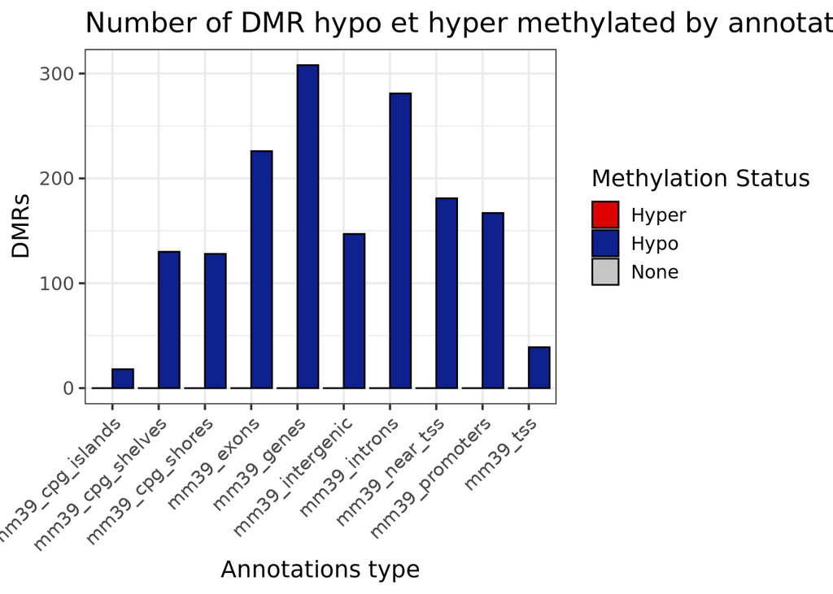

```r
if(length(sigdmr) > 0){
  list_annot_type <- NULL
  list_nb_dmr_hypo <- NULL
  list_nb_dmr_hyper <- NULL

  for(type in names(table(sigdmr_annot$annot$type))){
    dmr_type <- sigdmr_annot[sigdmr_annot$annot$type == type, ]
    nb_dmr_hypo <- length(table(dmr_type[dmr_type$stat < 0,]))
    nb_dmr_hyper <- length(table(dmr_type[dmr_type$stat > 0,]))
    list_annot_type <- c(list_annot_type, type)
    list_nb_dmr_hypo <- c(list_nb_dmr_hypo, nb_dmr_hypo)
    list_nb_dmr_hyper <- c(list_nb_dmr_hyper, nb_dmr_hyper)
  }

  df_dmr_annot <- data.frame(list_annot_type, list_nb_dmr_hyper, list_nb_dmr_hypo)
  colnames(df_dmr_annot) <- c("Annot_type", "Hyper", "Hypo")
  df_dmr_annot_long <- pivot_longer(df_dmr_annot, cols = c(Hyper, Hypo), names_to = "Meth_status", values_to = "Nb_DMRs")

  hist_dmr_annot <- ggplot(df_dmr_annot_long, aes(x = Annot_type, y = Nb_DMRs, fill = Meth_status)) +
                            geom_bar(position = "dodge" , stat = "identity", colour = "black") +
                            labs(title = "Number of DMR hypo et hyper methylated by annotations types",
                                 x = "Annotations type",
                                 y = "DMRs") +
                            guides(fill=guide_legend(title="Methylation Status")) +
                            theme_bw(base_size = 14) +
                            scale_fill_manual("", values=c('Hyper' = hyper.color,
                                                           'Hypo' = hypo.color,
                                                           'None' = not.color)) +
                            theme(axis.text.x = element_text(angle = 45, vjust = 1, hjust=1))
}else{
  print("No candidate, try to modifie parameters")
  hist_dmr_annot <- data.frame()
}

hist_dmr_annot
```

```r
suppressWarnings(rm(list_annot_type))
suppressWarnings(rm(list_nb_dmr_hypo))
suppressWarnings(rm(list_nb_dmr_hyper))
suppressWarnings(rm(df_dmr_annot, df_dmr_annot_long))
```

# 13 Exporting results to CSV files

Generate 3 CSV files, one for all DMRs, one for significant DMRs and one for significant DMRS with genes annotations

```r
if(notempty.dmr){
  write.csv(as.data.frame(dmr_obj), file= paste0(results_path, "DMR/",  CONDI, "_DMRs.csv"))
}else{
  print("Impossible to export results, no candidate DMR, try to modifie parameters")
}
if(length(sigdmr) > 0){
  write.csv(as.data.frame(sigdmr), file= paste0(results_path, "DMR/",  CONDI,  "_significant_DMRs.csv"))
}else{
  print("Impossible to export results, no significant DMR, try to modifie parameters")
}
if(length(sigdmr_annot_genes) > 0){
  write.csv(as.data.frame(sigdmr_annot_genes), file= paste0(results_path, "DMR/",  CONDI,  "_significant_annot_DMRs.csv"))
}else{
  print("Impossible to export results, no significant DMR with genes annotations, try to modifie parameters")
}
```

# 14 Save RData

Saves the whole R session of the script (variables, objects …)  
at the end of its execution. The RData file produced can then be opened in a local environment (if you have enough space)  
to make modifications. For example to retouch figures.

```r
save.image(file = rdata_out)
```

[session information not shown]

# 16 helpful links

- [UMR7216 Epigenetics And Cell Fate](http://parisepigenetics.com/)
- [BiBs : Bioinformatics and Biostatistics Lab](https://epigenetics.u-paris.fr/fr/bibs-bioinformatique-et-biostatistiques/)
- [WGBSFLOW Github](https://github.com/parisepigenetics/WGBSflow)
- [Methylator Github](https://github.com/parisepigenetics/Methylator)